# Lab4

## Лабораторная работа № 4

### Андрюшина Мария, 932001

### Аренда велосипедов

```python
import pandas as pd
import numpy as np
import matplotlib.pyplot as plt
import seaborn as sns
from sklearn.preprocessing import MinMaxScaler
from sklearn.metrics import silhouette_score
from sklearn.cluster import KMeans, AgglomerativeClustering, DBSCAN
```

```python
import warnings
warnings.filterwarnings('ignore')
```

### Работа с данными

```python
df = pd.read_csv('hour.csv', index_col = 0)
df.head()
```

| instant | dteday | season | yr | mnth | hr | holiday | weekday | workingday | weathersit | temp | atemp | hum | windspeed | casual | registered | cnt |
| --- | --- | --- | --- | --- | --- | --- | --- | --- | --- | --- | --- | --- | --- | --- | --- | --- |
| 1 | 2011-01-01 | 1 | 0 | 1 | 0 | 0 | 6 | 0 | 1 | 0.24 | 0.2879 | 0.81 | 0.0 | 3 | 13 | 16 |
| 2 | 2011-01-01 | 1 | 0 | 1 | 1 | 0 | 6 | 0 | 1 | 0.22 | 0.2727 | 0.80 | 0.0 | 8 | 32 | 40 |
| 3 | 2011-01-01 | 1 | 0 | 1 | 2 | 0 | 6 | 0 | 1 | 0.22 | 0.2727 | 0.80 | 0.0 | 5 | 27 | 32 |
| 4 | 2011-01-01 | 1 | 0 | 1 | 3 | 0 | 6 | 0 | 1 | 0.24 | 0.2879 | 0.75 | 0.0 | 3 | 10 | 13 |
| 5 | 2011-01-01 | 1 | 0 | 1 | 4 | 0 | 6 | 0 | 1 | 0.24 | 0.2879 | 0.75 | 0.0 | 0 | 1 | 1 |

```python
df.describe()
```

|  | season | yr | mnth | hr | holiday | weekday | workingday | weathersit | temp | atemp | hum | windspeed | casual | registered | cnt |
| --- | --- | --- | --- | --- | --- | --- | --- | --- | --- | --- | --- | --- | --- | --- | --- |
| count | 17379.000000 | 17379.000000 | 17379.000000 | 17379.000000 | 17379.000000 | 17379.000000 | 17379.000000 | 17379.000000 | 17379.000000 | 17379.000000 | 17379.000000 | 17379.000000 | 17379.000000 | 17379.000000 | 17379.000000 |
| mean | 2.501640 | 0.502561 | 6.537775 | 11.546752 | 0.028770 | 3.003683 | 0.682721 | 1.425283 | 0.496987 | 0.475775 | 0.627229 | 0.190098 | 35.676218 | 153.786869 | 189.463088 |
| std | 1.106918 | 0.500008 | 3.438776 | 6.914405 | 0.167165 | 2.005771 | 0.465431 | 0.639357 | 0.192556 | 0.171850 | 0.192930 | 0.122340 | 49.305030 | 151.357286 | 181.387599 |
| min | 1.000000 | 0.000000 | 1.000000 | 0.000000 | 0.000000 | 0.000000 | 0.000000 | 1.000000 | 0.020000 | 0.000000 | 0.000000 | 0.000000 | 0.000000 | 0.000000 | 1.000000 |
| 25% | 2.000000 | 0.000000 | 4.000000 | 6.000000 | 0.000000 | 1.000000 | 0.000000 | 1.000000 | 0.340000 | 0.333300 | 0.480000 | 0.104500 | 4.000000 | 34.000000 | 40.000000 |
| 50% | 3.000000 | 1.000000 | 7.000000 | 12.000000 | 0.000000 | 3.000000 | 1.000000 | 1.000000 | 0.500000 | 0.484800 | 0.630000 | 0.194000 | 17.000000 | 115.000000 | 142.000000 |
| 75% | 3.000000 | 1.000000 | 10.000000 | 18.000000 | 0.000000 | 5.000000 | 1.000000 | 2.000000 | 0.660000 | 0.621200 | 0.780000 | 0.253700 | 48.000000 | 220.000000 | 281.000000 |
| max | 4.000000 | 1.000000 | 12.000000 | 23.000000 | 1.000000 | 6.000000 | 1.000000 | 4.000000 | 1.000000 | 1.000000 | 1.000000 | 0.850700 | 367.000000 | 886.000000 | 977.000000 |

```python
df.info()
```

```
<class 'pandas.core.frame.DataFrame'>
Index: 17379 entries, 1 to 17379
Data columns (total 16 columns):
 #   Column      Non-Null Count  Dtype
---  ------      --------------  -----
 0   dteday      17379 non-null  object
 1   season      17379 non-null  int64
 2   yr          17379 non-null  int64
 3   mnth        17379 non-null  int64
 4   hr          17379 non-null  int64
 5   holiday     17379 non-null  int64
 6   weekday     17379 non-null  int64
 7   workingday  17379 non-null  int64
 8   weathersit  17379 non-null  int64
 9   temp        17379 non-null  float64
 10  atemp       17379 non-null  float64
 11  hum         17379 non-null  float64
 12  windspeed   17379 non-null  float64
 13  casual      17379 non-null  int64
 14  registered  17379 non-null  int64
 15  cnt         17379 non-null  int64
dtypes: float64(4), int64(11), object(1)
memory usage: 2.3+ MB
```

```python
df.isnull().sum()/df.shape[0]
```

```
dteday        0.0
season        0.0
yr            0.0
mnth          0.0
hr            0.0
holiday       0.0
weekday       0.0
workingday    0.0
weathersit    0.0
temp          0.0
atemp         0.0
hum           0.0
windspeed     0.0
casual        0.0
registered    0.0
cnt           0.0
dtype: float64
```

Пропущенных значений нет

```python
df['dteday'] = pd.to_datetime(df['dteday'])
df['day'] = df['dteday'].dt.day
df = df.drop(['dteday'], axis=1)
```

Построим тепловую карту для всех признаков:

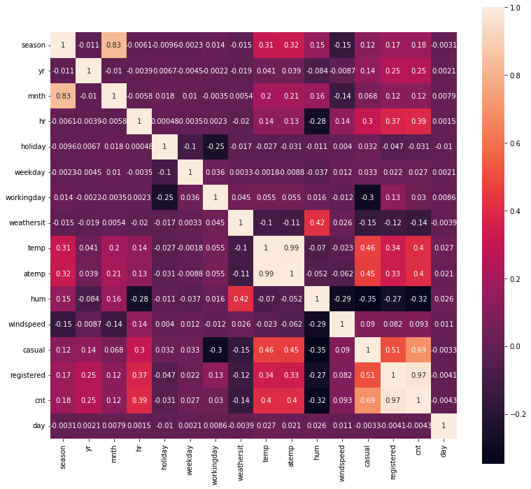

```python
plt.figure(figsize=(13, 12))
sns.heatmap(df.corr(), annot = True, square=True)
```

Возьмём два признака: hum и atemp

```python
features = ['hum', 'atemp']
```

```python
X = df.copy()
X = X[features]
X
```

| instant | hum | atemp |
| --- | --- | --- |
| 1 | 0.81 | 0.2879 |
| 2 | 0.80 | 0.2727 |
| 3 | 0.80 | 0.2727 |
| 4 | 0.75 | 0.2879 |
| 5 | 0.75 | 0.2879 |
| ... | ... | ... |
| 17375 | 0.60 | 0.2576 |
| 17376 | 0.60 | 0.2576 |
| 17377 | 0.60 | 0.2576 |
| 17378 | 0.56 | 0.2727 |
| 17379 | 0.65 | 0.2727 |

17379 rows × 2 columns

```python
min_max_scaler = MinMaxScaler()
X = min_max_scaler.fit_transform(X)
```

```python
X = pd.DataFrame(X, columns=[features])
X.head()
```

|  | hum | atemp |
| --- | --- | --- |
| 0 | 0.81 | 0.2879 |
| 1 | 0.80 | 0.2727 |
| 2 | 0.80 | 0.2727 |
| 3 | 0.75 | 0.2879 |
| 4 | 0.75 | 0.2879 |

### K-means

Подберём оптимальное количество кластеров:

```python
df_n_kmeans = pd.DataFrame(columns=['n', 'score'])
for i in range(2, 9):
    kmeans = KMeans(n_clusters=i, random_state=77)
    preds = kmeans.fit_predict(X)
    score = round(silhouette_score(X, preds), 3)
    print('Количество кластеров:', i)
    print('Коэффициент силуэта:', score)
    df_n_kmeans.loc[len(df_n_kmeans.index)] = [i, score]
df_n_kmeans
```

```
Количество кластеров: 2
Коэффициент силуэта: 0.368
Количество кластеров: 3
Коэффициент силуэта: 0.415
Количество кластеров: 4
Коэффициент силуэта: 0.382
Количество кластеров: 5
Коэффициент силуэта: 0.363
Количество кластеров: 6
Коэффициент силуэта: 0.355
Количество кластеров: 7
Коэффициент силуэта: 0.381
Количество кластеров: 8
Коэффициент силуэта: 0.371
```

|  | n | score |
| --- | --- | --- |
| 0 | 2.0 | 0.368 |
| 1 | 3.0 | 0.415 |
| 2 | 4.0 | 0.382 |
| 3 | 5.0 | 0.363 |
| 4 | 6.0 | 0.355 |
| 5 | 7.0 | 0.381 |
| 6 | 8.0 | 0.371 |

```
No artists with labels found to put in legend.  Note that artists whose label start with an underscore are ignored when legend() is called with no argument.
```

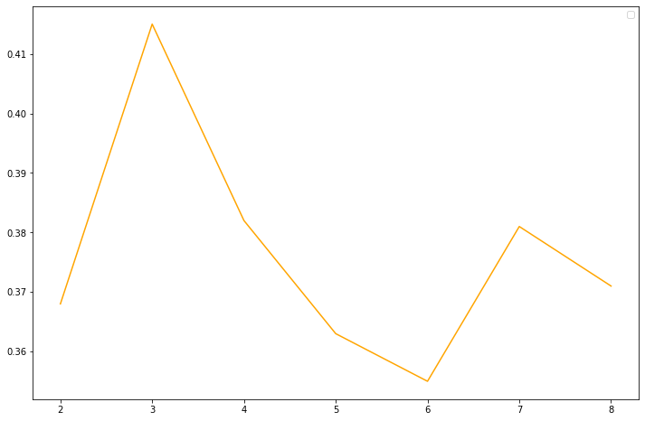

```python
plt.figure(figsize=(12,8))
plt.plot(df_n_kmeans['n'].values,df_n_kmeans['score'].values, color='orange')
plt.legend()
plt.show()
```

Оптимальное количество кластеров равно 3.

Подберем параметр n_init:

```python
df_init_kmeans = pd.DataFrame(columns=['n', 'score'])
for i in range (6, 15, 2):
    kmeans = KMeans(n_clusters=3, n_init = i, random_state=77)
    preds = kmeans.fit_predict(X)
    score = round(silhouette_score(X, preds), 5)
    print(i)
    print('Коэффициент силуэта:', score)
    df_init_kmeans.loc[len(df_init_kmeans.index)] = [i, score]
df_init_kmeans
```

```
6
Коэффициент силуэта: 0.41377
8
Коэффициент силуэта: 0.41457
10
Коэффициент силуэта: 0.41457
12
Коэффициент силуэта: 0.41443
14
Коэффициент силуэта: 0.41443
```

|  | n | score |
| --- | --- | --- |
| 0 | 6.0 | 0.41377 |
| 1 | 8.0 | 0.41457 |
| 2 | 10.0 | 0.41457 |
| 3 | 12.0 | 0.41443 |
| 4 | 14.0 | 0.41443 |

Оптимальное значение для параметра n_init равно 10.

Построим модель KMeans с учетом подобранных параметров:

```python
kmeans = KMeans(n_clusters = 3, n_init = 10, random_state = 77)
```

```python
preds = kmeans.fit_predict(X)
```

```python
score = silhouette_score(X, preds)
print('Коэффициент силуэта: ', score)
```

```
Коэффициент силуэта:  0.4145711290093497
```

```python
kmeans.cluster_centers_
```

```
array([[0.81249179, 0.47666284],
       [0.48592637, 0.64978989],
       [0.49938318, 0.30105962]])
```

```python
kmeans.fit(X)
```

```
KMeans(n_clusters=3, random_state=77)
```

Построим центроиды кластеров на графике:

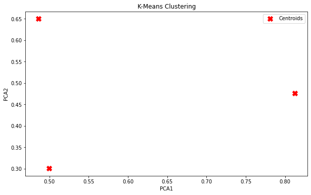

```python
plt.figure(figsize=(10,6))
centroids = kmeans.cluster_centers_
plt.scatter(centroids[:, 0], centroids[:, 1], marker = 'X', c = 'red', s = 100, label = 'Centroids')
plt.title('K-Means Clustering')
plt.xlabel('PCA1')
plt.ylabel('PCA2')
plt.legend()
plt.show()
```

Построим на графике кластеры:

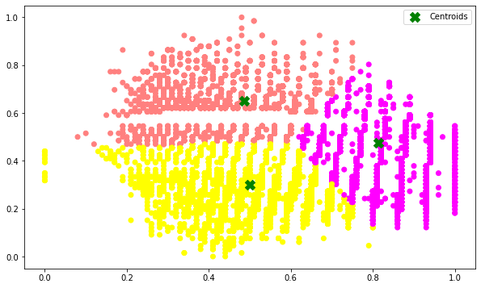

```python
plt.figure(figsize = (10,6))
plt.scatter(X.iloc[:,0], X.iloc[:,1], c = kmeans.labels_, cmap = 'spring')
plt.scatter(kmeans.cluster_centers_[:,0], kmeans.cluster_centers_[:,1], s = 150, c = 'green', marker = 'X', label = 'Centroids')
plt.legend(loc = 'upper right')
```

### Вывод

При создании модели KMeans использовались следующие гиперпараметры: n_clusters = 3, n_init = 10, random_state = 77. Коэффициент силуэта равен 0.415. На графике выделены три кластера примерно одинакового размера. Расстояние между центроидами кластеров примерно одинаковое.

### Аггломеративная кластеризация

Подберём оптимальное количество кластеров:

```python
df_n_agglom_clust = pd.DataFrame(columns=['n', 'score'])
for i in range(2, 9):
    agglom_clust = AgglomerativeClustering(n_clusters=i)
    preds = agglom_clust.fit_predict(X)
    score = round(silhouette_score(X, preds), 3)
    print('Количество кластеров:', i)
    print('Коэффициент силуэта:', score)
    df_n_agglom_clust.loc[len(df_n_agglom_clust.index)] = [i, score]
df_n_agglom_clust
```

```
Количество кластеров: 2
Коэффициент силуэта: 0.365
Количество кластеров: 3
Коэффициент силуэта: 0.356
Количество кластеров: 4
Коэффициент силуэта: 0.332
Количество кластеров: 5
Коэффициент силуэта: 0.32
Количество кластеров: 6
Коэффициент силуэта: 0.316
Количество кластеров: 7
Коэффициент силуэта: 0.346
Количество кластеров: 8
Коэффициент силуэта: 0.335
```

|  | n | score |
| --- | --- | --- |
| 0 | 2.0 | 0.365 |
| 1 | 3.0 | 0.356 |
| 2 | 4.0 | 0.332 |
| 3 | 5.0 | 0.320 |
| 4 | 6.0 | 0.316 |
| 5 | 7.0 | 0.346 |
| 6 | 8.0 | 0.335 |

```
No artists with labels found to put in legend.  Note that artists whose label start with an underscore are ignored when legend() is called with no argument.
```

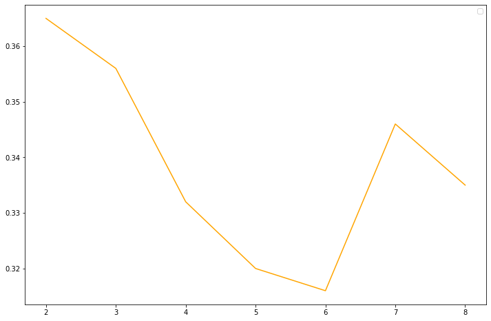

```python
plt.figure(figsize=(12,8))
plt.plot(df_n_agglom_clust['n'].values,df_n_agglom_clust['score'].values, color='orange')
plt.legend()
plt.show()
```

Оптимальное количество кластеров равно 2.

Построим модель AgglomerativeClustering с учетом подобранных параметров:

```python
agglom_clust = AgglomerativeClustering(n_clusters=2)
agglom_clust.fit(X)
```

```
AgglomerativeClustering()
```

```python
agglom_clust_labels = agglom_clust.labels_
```

```python
score = silhouette_score(X, agglom_clust.fit_predict(X))
print('Коэффициент силуэта: ', score)
```

```
Коэффициент силуэта:  0.36511934599116525
```

Построим на графике кластеры:

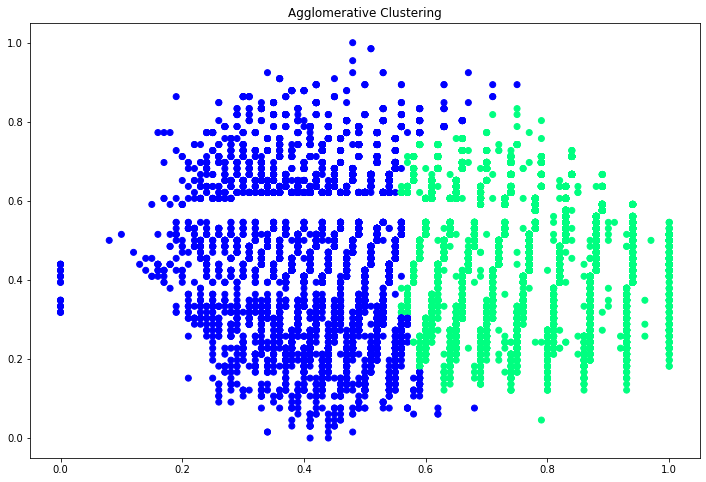

```python
plt.figure(figsize=(12,8))
plt.scatter(X.iloc[:, 0], X.iloc[:, 1], c=ward_labels, cmap='winter')
plt.title("Agglomerative Clustering")
plt.show()
```

### Вывод

При создании модели AgglomerativeClustering использовались следующие гиперпараметры: n_clusters=2. Коэффициент силуэта равен 0.365. На графике выделены два кластера примерно одинакового размера.

### DBScan

Подберём оптимальные параметры модели:

```python
score1 = 0
for eps in np.arange(0.1, 0.5, 0.1):
    for min_samples in range(1, 5):
        dbscan = DBSCAN(eps = eps, min_samples = min_samples, n_jobs = -1)
        preds = dbscan.fit_predict(X)
        n_clusters = len(set(preds)) - (1 if -1 in preds else 0)
        if n_clusters < 2:
            continue
        score = silhouette_score(X, preds)
        if score > score1:
            score1 = score
            eps1 = eps
            min_samples1 = min_samples
print('eps: ', eps1)
print('min_samples: ', min_samples1)
print('Коэффициент силуэта: ', score1)
```

```
eps:  0.1
min_samples:  1
Коэффициент силуэта:  0.45729474310063295
```

Оптимальные значения параметров: eps = 0.1, min_samples = 1.

Построим модель DBSCAN с учетом подобранных параметров:

```python
dbscan = DBSCAN(eps = 0.1, min_samples = 1)
preds = dbscan.fit_predict(X)
```

```python
score = silhouette_score(X, preds)
print('Коэффициент силуэта: ', score)
```

```
Коэффициент силуэта:  0.45729474310063295
```

Построим на графике кластеры:

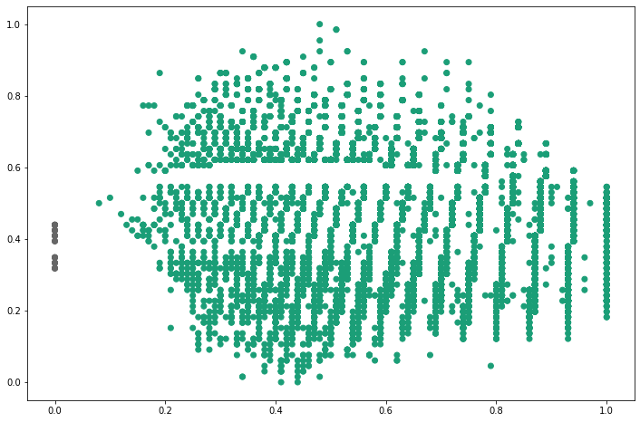

```python
plt.figure(figsize=(12,8))
plt.scatter(X.iloc[:,0], X.iloc[:,1], c=clusters, cmap='Dark2')
plt.show()
```

### Вывод

При создании модели DBSCAN использовались следующие гиперпараметры: eps = 0.1, min_samples = 1. Коэффициент силуэта равен 0.457. На графике выделены два кластера. Первый имеет меньший размер, но при этом существенно отдалён от второго.

### Общий вывод

Лучше всех показала себя модель DBSCAN с коэффициентом силуэта, равным 0.457. При этом число элементов в первом кластере сильно отличается от числа элементов во втором.

Модели K-means и AgglomerativeClustering выделяли кластеры более равномерно. В каждом кластере получилось примерно одинаковое количество элементов.